# Reproducible Research Course Project 2

[output not shown]

## There are two goals of this analysis:

```
## - identify the weather events that are most harmful with respect to population health
## - identify the weather events that have the greatest economic consequences.
```

## Based on our analysis

[output not shown]

## Data Processing

#The data source is in the form of a comma-separated-value file compressed via the bzip2 algorithm to reduce its size. It is possible to download the source file from the course web site: [Storm Data](https://d396qusza40orc.cloudfront.net/repdata%2Fdata%2FStormData.csv.bz2)

```r
# downloading data needed ----------------------------------------------------------------
library(dplyr)
library(ggplot2)
library(data.table)
library(lubridate)
library(rmarkdown)

Url_data <- "https://d396qusza40orc.cloudfront.net/repdata%2Fdata%2FStormData.csv.bz2"
filename <- "repdata_data_StormData.csv.bz2"
download.file(Url_data, filename)
# reading data
My_data <- fread(file = filename, sep = "auto", header = TRUE)
My_data <- data.table(My_data) #transfer back to data.table
```

## Additional documentation on the database was provided here:

- [National Weather Service Storm Data Documentation](https://d396qusza40orc.cloudfront.net/repdata%2Fpeer2_doc%2Fpd01016005curr.pdf)
- [National Climatic Data Center Storm Events FAQ](https://d396qusza40orc.cloudfront.net/repdata%2Fpeer2_doc%2FNCDC%20Storm%20Events-FAQ%20Page.pdf)

### 1. According to NOAA, the data recording start from Jan. 1950. At that time, they recorded only one event type - tornado. They added more events gradually, and only from Jan 1996 they started recording all events type. Since our objective is comparing the effects of different weather events, we need only to include events that started not earlier than Jan 1996.

```r
 # Change date formats and filter data for dates
  My_data$BGN_DATE <- mdy_hms(My_data$BGN_DATE)
  My_data <- My_data[BGN_DATE > "1995-12-31"]
```

### 2. Based on the above mentioned documentation and preliminary exploration of raw data with ‘str’, ‘names’, ‘table’, ‘dim’, ‘head’, ‘range’ and other similar functions we can conclude that there are 7 variables we are interested in regarding the two questions.

Namely: EVTYPE, FATALITIES, INJURIES, PROPDMG, PROPDMGEXP, CROPDMG, CROPDMGEXP.  
Therefore, we can limit our data to these variables.

```r
# Select the needed columns
  My_data <- My_data[, colnames(My_data) %in%
                       c("EVTYPE", "FATALITIES", "INJURIES", "PROPDMG", "PROPDMGEXP", "CROPDMG", "CROPDMGEXP")
                     , with=FALSE]
```

## Contents of data now are as follows:

EVTYPE = type of event  
FATALITIES = number of fatalities  
INJURIES = number of injuries  
PROPDMG = the size of property damage  
PROPDMGEXP = the exponent values for ‘PROPDMG’ (property damage)  
CROPDMG = the size of crop damage  
CROPDMGEXP = the exponent values for ‘CROPDMG’ (crop damage)

## 3. There are almost 1000 unique event types in EVTYPE column. Therefore, it is better to limit database to a reasonable number. We can make it by capitalizing all letters in EVTYPE column as well as subsetting only non-zero data regarding our target numbers.

```r
#cleaning event types names
  My_data$EVTYPE <- toupper(My_data$EVTYPE)

  # eliminating zero data
  My_data <- My_data[FATALITIES != 0 &
                       INJURIES != 0 &
                       PROPDMG != 0 &
                       CROPDMG != 0]
```

## Population health data processing

### We aggregate fatalities and injuries numbers in order to identify TOP-10 events contributing the total people loss:

```r
  #pivot table with dplyr
  My_data <- data.frame(My_data) #transfer back to data.frame
  Health_data <- My_data %>% group_by(EVTYPE) %>%
                             summarise(FATALITIES = sum(FATALITIES),
                                       INJURIES = sum(INJURIES))
  Health_data <- data.table(Health_data)  #transfer back to data.table
  Health_data <- Health_data[, PEOPLE_LOSS := FATALITIES + INJURIES, by = "EVTYPE"]
  # descending order by PEOPLE_LOSS
  Health_data <- Health_data[order(Health_data$PEOPLE_LOSS, decreasing = TRUE), ]
  #top 10 by PEOPLE_LOSS
  Top10.EVTYPE.People <- top_n(Health_data, 10)
knitr::kable(Top10.EVTYPE.People, format = "markdown")
```

| EVTYPE | FATALITIES | INJURIES | PEOPLE_LOSS |
| --- | --- | --- | --- |
| FLOOD | 37 | 2487 | 2524 |
| TORNADO | 160 | 1332 | 1492 |
| HURRICANE/TYPHOON | 22 | 884 | 906 |
| TROPICAL STORM | 7 | 266 | 273 |
| FLASH FLOOD | 18 | 214 | 232 |
| TSUNAMI | 32 | 129 | 161 |
| WILDFIRE | 31 | 124 | 155 |
| EXCESSIVE HEAT | 46 | 18 | 64 |
| HIGH WIND | 10 | 51 | 61 |
| HEAVY SNOW | 4 | 38 | 42 |

## Economic consequences data processing

The number/letter in the exponent value columns (PROPDMGEXP and CROPDMGEXP) represents the power of ten (10^The number). It means that the total size of damage is the product of PROPDMG and CROPDMG and figure 10 in the power corresponding to exponent value.

## Exponent values are:

- numbers from one to ten
- letters (B or b = Billion, M or m = Million, K or k = Thousand, H or h = Hundred)
- and symbols “-”, “+” and “?” which refers to less than, greater than and low certainty. We have the option to ignore these three symbols altogether.

## We transform letters and symbols to numbers:

```r
 #transform letters and symbols to numbers
  My_data$PROPDMGEXP <- gsub("[Hh]", "2", My_data$PROPDMGEXP)
  My_data$PROPDMGEXP <- gsub("[Kk]", "3", My_data$PROPDMGEXP)
  My_data$PROPDMGEXP <- gsub("[Mm]", "6", My_data$PROPDMGEXP)
  My_data$PROPDMGEXP <- gsub("[Bb]", "9", My_data$PROPDMGEXP)
  My_data$PROPDMGEXP <- gsub("\\+", "1", My_data$PROPDMGEXP)
  My_data$PROPDMGEXP <- gsub("\\?|\\-|\\ ", "0",  My_data$PROPDMGEXP)
  My_data$PROPDMGEXP <- as.numeric(My_data$PROPDMGEXP)

  My_data$CROPDMGEXP <- gsub("[Hh]", "2", My_data$CROPDMGEXP)
  My_data$CROPDMGEXP <- gsub("[Kk]", "3", My_data$CROPDMGEXP)
  My_data$CROPDMGEXP <- gsub("[Mm]", "6", My_data$CROPDMGEXP)
  My_data$CROPDMGEXP <- gsub("[Bb]", "9", My_data$CROPDMGEXP)
  My_data$CROPDMGEXP <- gsub("\\+", "1", My_data$CROPDMGEXP)
  My_data$CROPDMGEXP <- gsub("\\-|\\?|\\ ", "0", My_data$CROPDMGEXP)
  My_data$CROPDMGEXP <- as.numeric(My_data$CROPDMGEXP)
```

## At last, we create new values of total property damage and total crop damage for analysis (we need ‘dplr’ package for that).

```r
#creating total damage values
 My_data$PROPDMGEXP[is.na(My_data$PROPDMGEXP)] <- 0
  My_data$CROPDMGEXP[is.na(My_data$CROPDMGEXP)] <- 0

  #Total damage values
  My_data <- mutate(My_data,
                      PROPDMGTOTAL = PROPDMG * (10 ^ PROPDMGEXP),
                      CROPDMGTOTAL = CROPDMG * (10 ^ CROPDMGEXP))
```

## Now we aggregate property and crop damage numbers in order to identify TOP-10 events contributing the total economic loss:

```r
 #Economic_data: Let us now analyze the date from above
  #pivot table with dplyr
  Economic_data <- My_data %>% group_by(EVTYPE) %>%
                               summarise(PROPDMGTOTAL = sum(PROPDMGTOTAL),
                                         CROPDMGTOTAL = sum(CROPDMGTOTAL))
  Economic_data <- data.table(Economic_data)  #transfer back to data.table
  Economic_data <- Economic_data[, ECONOMIC_LOSS := PROPDMGTOTAL + CROPDMGTOTAL, by = "EVTYPE"]
  # descending order by ECONOMIC_LOSS
  Economic_data <- Economic_data[order(Economic_data$ECONOMIC_LOSS, decreasing = TRUE), ]
  #top 10 by ECONOMIC_LOSS
  Top10.EVTYPE.economy <- top_n(Economic_data, 10)
knitr::kable(Top10.EVTYPE.economy, format = "markdown")
```

| EVTYPE | PROPDMGTOTAL | CROPDMGTOTAL | ECONOMIC_LOSS |
| --- | --- | --- | --- |
| HURRICANE/TYPHOON | 11300000000 | 1795000000 | 13095000000 |
| WILDFIRE | 1165120000 | 75150000 | 1240270000 |
| HIGH WIND | 948190000 | 222930000 | 1171120000 |
| TORNADO | 1040902000 | 42920000 | 1083822000 |
| TROPICAL STORM | 628470000 | 121690000 | 750160000 |
| EXCESSIVE HEAT | 170000 | 492400000 | 492570000 |
| HURRICANE | 140250000 | 127000000 | 267250000 |
| FLOOD | 210500000 | 12180500 | 222680500 |
| FLASH FLOOD | 94657000 | 2235000 | 96892000 |
| TSUNAMI | 81000000 | 20000 | 81020000 |

## Results

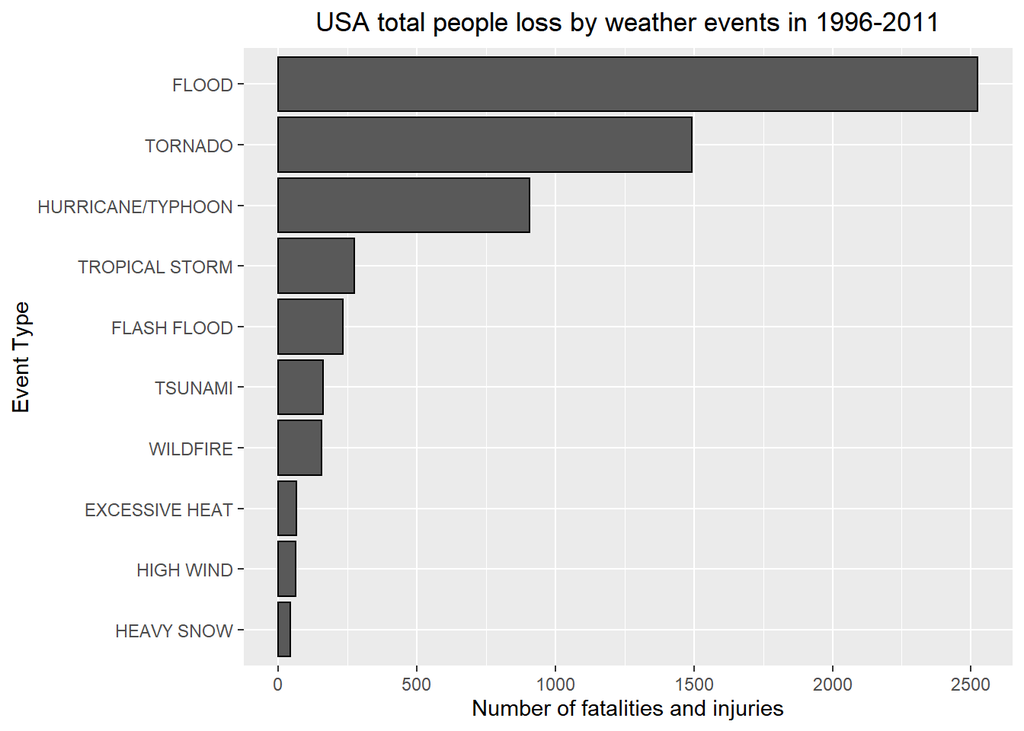

```r
 #plotting health loss -> HL

  HL <- ggplot(data = Top10.EVTYPE.People, aes(x = reorder(EVTYPE, PEOPLE_LOSS), y = PEOPLE_LOSS)) +
        geom_bar(stat = "identity", colour = "black") +
        labs(title = "USA total people loss by weather events in 1996-2011") +
        theme(plot.title = element_text(hjust = 0.5)) +
        labs(y = "Number of fatalities and injuries", x = "Event Type") +
        coord_flip()

  HL
```

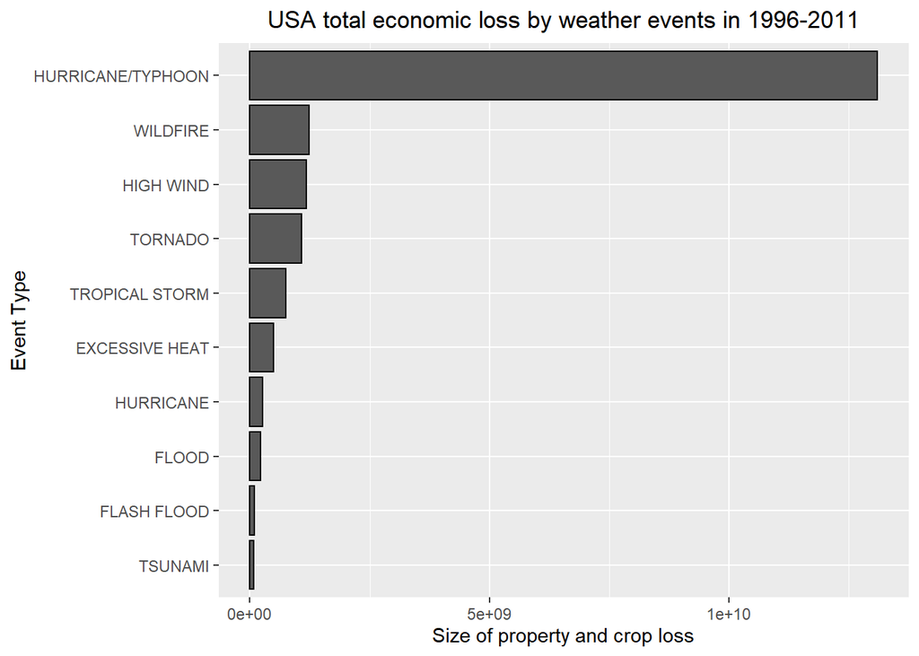

```r
#plotting economic loss -> EL

  EL <- ggplot(data = Top10.EVTYPE.economy, aes(x = reorder(EVTYPE, ECONOMIC_LOSS), y = ECONOMIC_LOSS)) +
        geom_bar(stat = "identity", colour = "black") +
        labs(title = "USA total economic loss by weather events in 1996-2011") +
        theme(plot.title = element_text(hjust = 0.5)) +
        labs(y = "Size of property and crop loss", x = "Event Type") +
        coord_flip()

  EL
```